# 新任教員による研究紹介セミナー

有賀ゆうアニース (文化構想学部 現代人間論系)

2026-06-03

## 自己紹介

- 氏名: 有賀ゆうアニース（あるが ゆうあにーす）
- 略歴: 1995年長野県生まれ。2018年早稲田大学文化構想学部卒業。2024年東京大学学際情報学府博士課程修了。博士（社会情報学）。2026年4月より現職。
- 所属: 文化構想学部現代人間論系 准教授 (任期付)
- 専門: 社会学、エスニシティ論
- 担当授業: エスニシティ論、差別論、「多様性を生きる人間」論ゼミ（エスニシティと現代社会）ほか

## 研究関心

- 日本と外国の両方にルーツをもつ人々にかかわる質的・量的研究に従事している。とくに以下に関心がある:
  - 移民の子孫・マイノリティとしてのかれらの社会への統合や差別
  - 現代のポピュラー文化やメディア上における人種・民族の表象

[figure not shown]

共著『国際社会学の技法』

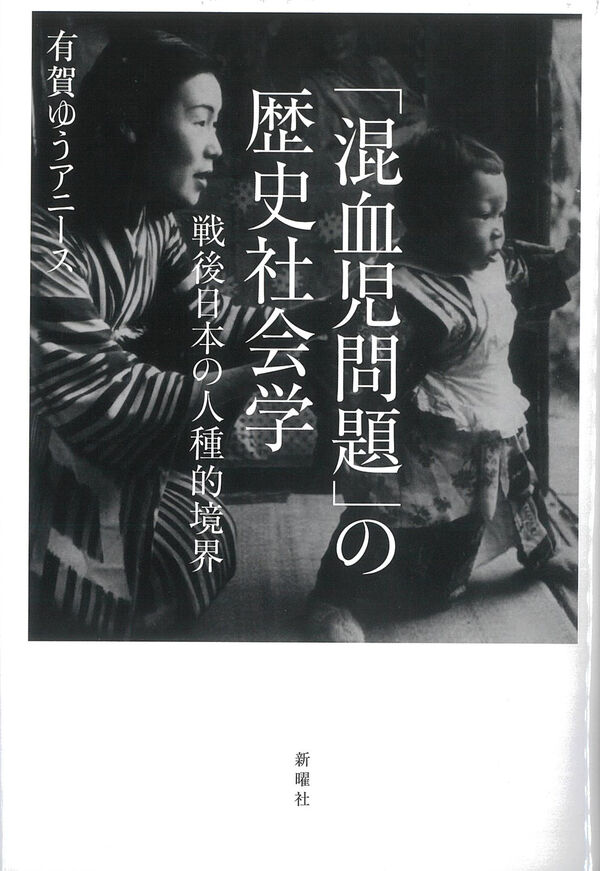

単著『「混血児問題」の歴史社会学』

[figure not shown]

共著『広告文化の社会学』

## 最近の研究から①: 歴史研究・質的研究

**『「混血児問題」の歴史社会学』（2026年、新曜社）**

> 戦後日本は「日本人」と「混血児」の境界をいかに設定してきたか。ある歴史的・社会的文脈のもと、人種が他の属性や制度と結びつくことで、「混血児」はいかに包摂／排除されてきたのか。人種という境界が人々の経験を形づくる仕組みを明らかにする。

> ＊ 教育・福祉・移民等の政策やその現場で「混血児」がいかに処遇され、どのように人種の境界が形成されてきたのかを明らかにする。  
> ＊ 「人種差別」に限らず「差別」を考えるうえで、本書のアプローチは有効な示唆を与える。  
> ＊ 第六回東京大学而立賞受賞  
> （出所: www.shin-yo-sha.co.jp)

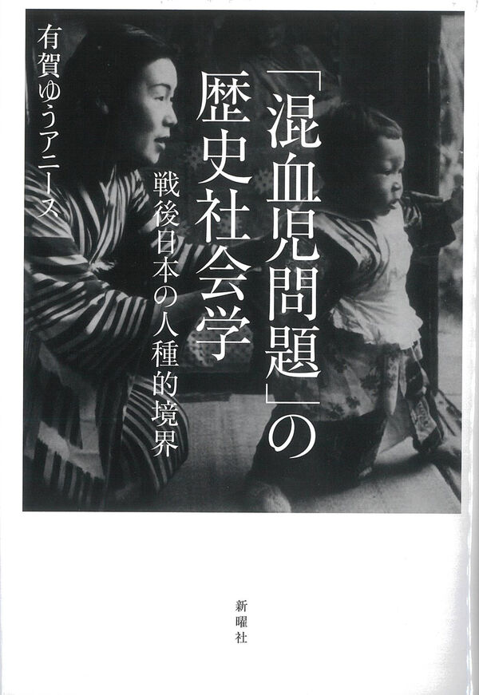

単著『「混血児問題」の歴史社会学』

## 最近の研究から②: メディア研究・量的研究

**「だれが「ハーフ」としてソーシャルメディア上で語るのか」『メディア研究』（2023年、103号）**

**「広告表現とエスニシティ」『広告文化の社会学：メディアと消費の文化論』（北樹出版、2024年）**

- 外国にルーツをもつ人々はマスメディア上でいかに表象されているのか
- ソーシャルメディア上での当事者の自己表象はマスメディア上の表象とどう異なるのか
- 白人系の過剰な表象、アジア系の過小な表象、各エスニシティへのステレオタイプの存続⋯⋯

[figure not shown]

共著『広告文化の社会学』

## 研究展望

- 現在行っているその他の研究
  - 若者世代へのインタビューによる、当事者のアイデンティティとその規定要因
  - マスメディアにおける人種・民族表象の内容分析
  - アンケートデータの二次分析による親子関係やいじめ被害の分析
- 今後の研究の方向性
  - メディア・教育・家庭・友人関係・国際移動といった社会的文脈が当事者のアイデンティティや統合にどう影響するかが当面の焦点
  - 日本社会におけるエスニシティ多様化とマイノリティ統合によって、日本人／外国人／ハーフ／外国ルーツ等々の境界がどう存続・変化していくかが究極的な関心